# The Emotikon Project: Model Complexification and PCA

Authors

Reinhold Kliegl

Phillip Alday

Published

2026-08-28

**Learning objectives** — this capstone pulls the course together on a large dataset. After working through it you will be able to:

- carry out a complete analysis: data preparation, plotting the main results, contrast specification, and model complexification;
- use PCA of the random effects to guide the random-effects structure;
- interpret a parsimonious model for the Emotikon fitness data.

**NoteBefore you start**

**Prerequisites:** Mixed Models Tutorial: Contrast Coding; Creating multi-panel plots.

**Datasets used:** `fggk21` (Emotikon; see the dataset catalog).

This script uses a subset of data reported in Fühner et al. (2021). To circumvent delays associated with model fitting we work with models that are less complex than those in the reference publication. All the data to reproduce the models in the publication are used here, too; the script requires only a few changes to specify the more complex models in the article.

The script is structured in three main sections:

1. **Setup** with reading and examining the data, plotting the main results, and specifying the contrasts for the fixed factor `Test`
2. a demonstration of **model complexification** to determine a parsimonious random-effect structure appropriate for and supported by the data, including also a quite elaborate demonstration of **principle component analyses (PCAs)** of levels (scores) and effects,
3. specification of **nested fixed effects or interactions** in the levels of another, superordinate factors.

# 1 Packages and functions

```julia
using AlgebraOfGraphics
using AlgebraOfGraphics: linear
using CairoMakie
using CategoricalArrays
using DataFrames
using MixedModels
using MixedModelsMakie
using MixedModelsMakie: simplelinreg
using Statistics
using StatsBase
using MixedModelsDatasets: dataset
using SMLP2026: fit_or_restore

const progress = isinteractive()
```

```
false
```

# 2 Preprocessing

Variable descriptions for `dataset(:fggk21)` — including the five `Test` levels and their units — are in the dataset catalog.

## 2.1 Read data

```julia
df = DataFrame(dataset(:fggk21))
transform!(df,
    :age => (x -> x .- 8.5) => :a1,
    :Sex => categorical => :Sex,
    :Test => categorical => :Test,
  )
levels!(df.Sex, ["male", "female"])
recode!(df.Sex, "male" => "Boys", "female" => "Girls")
levels!(df.Test, ["Run", "Star_r", "S20_r", "SLJ", "BPT"])
recode!(
  df.Test,
  "Run" => "Endurance",
  "Star_r" => "Coordination",
  "S20_r" => "Speed",
  "SLJ" => "PowerLOW",
  "BPT" => "PowerUP",
)
describe(df)
```

8×7 DataFrame

| Row | variable Symbol | mean Union… | min Any | median Union… | max Any | nmissing Int64 | eltype DataType |
| --- | --- | --- | --- | --- | --- | --- | --- |
| 1 | Cohort |  | 2011 |  | 2019 | 0 | String |
| 2 | School |  | S100043 |  | S800200 | 0 | String |
| 3 | Child |  | C002352 |  | C117966 | 0 | String |
| 4 | Sex |  | Boys |  | Girls | 0 | CategoricalValue{String, UInt32} |
| 5 | age | 8.56073 | 7.99452 | 8.55852 | 9.10609 | 0 | Float64 |
| 6 | Test |  | Endurance |  | PowerUP | 0 | CategoricalValue{String, UInt32} |
| 7 | score | 226.141 | 1.14152 | 4.65116 | 1530.0 | 0 | Float64 |
| 8 | a1 | 0.0607297 | -0.505476 | 0.0585216 | 0.606092 | 0 | Float64 |

### 2.1.1 Transformations

We center `age` at 8.5 years and compute z-scores for each `Test`. With these variables the data frame `df` contains all variables used for the final model in the original publication.

```julia
select!(groupby(df, :Test),  Not(:score), :score => zscore => :zScore)
```

525126×8 DataFrame

525101 rows omitted

| Row | Test Cat… | Cohort String | School String | Child String | Sex Cat… | age Float64 | a1 Float64 | zScore Float64 |
| --- | --- | --- | --- | --- | --- | --- | --- | --- |
| 1 | Speed | 2013 | S100067 | C002352 | Boys | 7.99452 | -0.505476 | 1.7913 |
| 2 | PowerUP | 2013 | S100067 | C002352 | Boys | 7.99452 | -0.505476 | -0.0622317 |
| 3 | PowerLOW | 2013 | S100067 | C002352 | Boys | 7.99452 | -0.505476 | -0.0336567 |
| 4 | Coordination | 2013 | S100067 | C002352 | Boys | 7.99452 | -0.505476 | 1.46874 |
| 5 | Endurance | 2013 | S100067 | C002352 | Boys | 7.99452 | -0.505476 | 0.331058 |
| 6 | Speed | 2013 | S100067 | C002353 | Boys | 7.99452 | -0.505476 | 1.15471 |
| 7 | PowerUP | 2013 | S100067 | C002353 | Boys | 7.99452 | -0.505476 | 0.498354 |
| 8 | PowerLOW | 2013 | S100067 | C002353 | Boys | 7.99452 | -0.505476 | -0.498822 |
| 9 | Coordination | 2013 | S100067 | C002353 | Boys | 7.99452 | -0.505476 | -0.9773 |
| 10 | Endurance | 2013 | S100067 | C002353 | Boys | 7.99452 | -0.505476 | 0.574056 |
| 11 | Speed | 2013 | S100067 | C002354 | Boys | 7.99452 | -0.505476 | 0.0551481 |
| 12 | PowerUP | 2013 | S100067 | C002354 | Boys | 7.99452 | -0.505476 | 0.218061 |
| 13 | PowerLOW | 2013 | S100067 | C002354 | Boys | 7.99452 | -0.505476 | -0.757248 |
| ⋮ | ⋮ | ⋮ | ⋮ | ⋮ | ⋮ | ⋮ | ⋮ | ⋮ |
| 525115 | Coordination | 2018 | S401470 | C117964 | Boys | 9.10609 | 0.606092 | -1.43175 |
| 525116 | Endurance | 2018 | S401470 | C117964 | Boys | 9.10609 | 0.606092 | -0.944681 |
| 525117 | Speed | 2018 | S401470 | C117965 | Girls | 9.10609 | 0.606092 | 0.31086 |
| 525118 | PowerUP | 2018 | S401470 | C117965 | Girls | 9.10609 | 0.606092 | 0.0779146 |
| 525119 | PowerLOW | 2018 | S401470 | C117965 | Girls | 9.10609 | 0.606092 | -0.137027 |
| 525120 | Coordination | 2018 | S401470 | C117965 | Girls | 9.10609 | 0.606092 | -1.8077 |
| 525121 | Endurance | 2018 | S401470 | C117965 | Girls | 9.10609 | 0.606092 | 0.513306 |
| 525122 | Speed | 2018 | S800200 | C117966 | Boys | 9.10609 | 0.606092 | 0.0551481 |
| 525123 | PowerUP | 2018 | S800200 | C117966 | Boys | 9.10609 | 0.606092 | 0.0779146 |
| 525124 | PowerLOW | 2018 | S800200 | C117966 | Boys | 9.10609 | 0.606092 | -1.32578 |
| 525125 | Coordination | 2018 | S800200 | C117966 | Boys | 9.10609 | 0.606092 | 0.473217 |
| 525126 | Endurance | 2018 | S800200 | C117966 | Boys | 9.10609 | 0.606092 | -0.0941883 |

**Tip**

The preprocessing steps above are also packaged as `SMLP2026.fggk21_preprocessed()`, so that other pages (e.g. the contrast-coding tutorial) can reuse them without repeating the code.

## 2.2 Extract a stratified subsample

For the purpose of the tutorial, we extract a random sample of 1000 boys and 1000 girls. `Child`, `School`, and `Cohort` are grouping variables. Traditionally, they are called random factors because the units (levels) of the factor are assumed to be a random sample from the population of their units (levels).

Cohort has only nine “groups” and could have been included as a set of polynomical fixed-effect contrasts rather than a random factor. This choice warrants a short excursion: The secular trends are very different for different tests and require the inclusion of interaction terms with `Test` contrasts (see Figure 4 in (Fühner et al., 2021). The authors opted to absorb these effects in cohort-related variance components for the `Test` contrasts and plan to address the details of secular changes in a separate analysis.

For complex designs, when they are in the theoretical focus of an article, factors and covariates should be specified as part of the fixed effects. If they are not in the theoretical focus, but serve as statistical control variables, they could be put in the RES - if supported by the data.

**Stratified sampling:** We build a table with one row per child, sample 1000 boys and 1000 girls from it without replacement, and then extract all of the sampled children’s test scores from `df`. Sampling whole children – rather than individual scores – preserves the within-child structure that by-`Child` random slopes rely on. This procedure is packaged as `SMLP2026.fggk21_teaching_sample()`; it uses a `StableRNG` with a fixed seed so that the stratification is reproducible across Julia versions (pass a different `seed` for a different pattern of results). The contrast-coding tutorial uses the same subsample, so estimates are directly comparable between the two pages.

```julia
using SMLP2026: fggk21_teaching_sample
dat = fggk21_teaching_sample(df)
```

9704×8 DataFrame

9679 rows omitted

| Row | Test Cat… | Cohort String | School String | Child String | Sex Cat… | age Float64 | a1 Float64 | zScore Float64 |
| --- | --- | --- | --- | --- | --- | --- | --- | --- |
| 1 | Speed | 2013 | S100432 | C002372 | Boys | 7.99452 | -0.505476 | 2.49861 |
| 2 | PowerUP | 2013 | S100432 | C002372 | Boys | 7.99452 | -0.505476 | 1.61952 |
| 3 | PowerLOW | 2013 | S100432 | C002372 | Boys | 7.99452 | -0.505476 | -1.06736 |
| 4 | Coordination | 2013 | S100432 | C002372 | Boys | 7.99452 | -0.505476 | 0.572288 |
| 5 | Endurance | 2013 | S100432 | C002372 | Boys | 7.99452 | -0.505476 | 0.628055 |
| 6 | Speed | 2013 | S100924 | C002412 | Girls | 7.99452 | -0.505476 | -0.861152 |
| 7 | PowerUP | 2013 | S100924 | C002412 | Girls | 7.99452 | -0.505476 | -0.90311 |
| 8 | PowerLOW | 2013 | S100924 | C002412 | Girls | 7.99452 | -0.505476 | -0.188712 |
| 9 | Coordination | 2013 | S100924 | C002412 | Girls | 7.99452 | -0.505476 | 0.190742 |
| 10 | Endurance | 2013 | S100924 | C002412 | Girls | 7.99452 | -0.505476 | -1.18768 |
| 11 | Speed | 2013 | S102295 | C002539 | Girls | 7.99452 | -0.505476 | -1.06685 |
| 12 | PowerUP | 2013 | S102295 | C002539 | Girls | 7.99452 | -0.505476 | -1.32355 |
| 13 | PowerLOW | 2013 | S102295 | C002539 | Girls | 7.99452 | -0.505476 | -2.87634 |
| ⋮ | ⋮ | ⋮ | ⋮ | ⋮ | ⋮ | ⋮ | ⋮ | ⋮ |
| 9693 | Coordination | 2018 | S106781 | C117692 | Boys | 9.10609 | 0.606092 | 0.538978 |
| 9694 | Endurance | 2018 | S106781 | C117692 | Boys | 9.10609 | 0.606092 | 0.938553 |
| 9695 | Speed | 2018 | S111302 | C117786 | Girls | 9.10609 | 0.606092 | 0.31086 |
| 9696 | PowerUP | 2018 | S111302 | C117786 | Girls | 9.10609 | 0.606092 | -0.622817 |
| 9697 | PowerLOW | 2018 | S111302 | C117786 | Girls | 9.10609 | 0.606092 | 1.1551 |
| 9698 | Coordination | 2018 | S111302 | C117786 | Girls | 9.10609 | 0.606092 | -1.39492 |
| 9699 | Endurance | 2018 | S111302 | C117786 | Girls | 9.10609 | 0.606092 | -0.154938 |
| 9700 | Speed | 2018 | S130370 | C117936 | Boys | 9.10609 | 0.606092 | 0.31086 |
| 9701 | PowerUP | 2018 | S130370 | C117936 | Boys | 9.10609 | 0.606092 | -0.482671 |
| 9702 | PowerLOW | 2018 | S130370 | C117936 | Boys | 9.10609 | 0.606092 | 0.224769 |
| 9703 | Coordination | 2018 | S130370 | C117936 | Boys | 9.10609 | 0.606092 | 0.572288 |
| 9704 | Endurance | 2018 | S130370 | C117936 | Boys | 9.10609 | 0.606092 | 0.452557 |

Due to missing scores for some tests we have about 3% less than 10,000 observations.

## 2.3 No evidence for `age x Sex x Test` interaction

The main results are captured in the figure constructed in this section. We build it both for the full data and the stratified subset.

```julia
df2 = combine(
  groupby(
    select(df, :, :age => ByRow(x -> round(x; digits=1)) => :age),
    [:Sex, :Test, :age],
  ),
  :zScore => mean => :zScore,
  :zScore => length => :n,
)
```

120×5 DataFrame

95 rows omitted

| Row | Sex Cat… | Test Cat… | age Float64 | zScore Float64 | n Int64 |
| --- | --- | --- | --- | --- | --- |
| 1 | Boys | Speed | 8.0 | -0.0265138 | 1223 |
| 2 | Boys | PowerUP | 8.0 | 0.026973 | 1227 |
| 3 | Boys | PowerLOW | 8.0 | 0.121609 | 1227 |
| 4 | Boys | Coordination | 8.0 | -0.0571726 | 1186 |
| 5 | Boys | Endurance | 8.0 | 0.292695 | 1210 |
| 6 | Girls | Speed | 8.0 | -0.35164 | 1411 |
| 7 | Girls | PowerUP | 8.0 | -0.610355 | 1417 |
| 8 | Girls | PowerLOW | 8.0 | -0.279872 | 1418 |
| 9 | Girls | Coordination | 8.0 | -0.268221 | 1381 |
| 10 | Girls | Endurance | 8.0 | -0.245573 | 1387 |
| 11 | Boys | Speed | 8.1 | 0.0608397 | 3042 |
| 12 | Boys | PowerUP | 8.1 | 0.0955413 | 3069 |
| 13 | Boys | PowerLOW | 8.1 | 0.123099 | 3069 |
| ⋮ | ⋮ | ⋮ | ⋮ | ⋮ | ⋮ |
| 109 | Boys | Coordination | 9.0 | 0.254973 | 4049 |
| 110 | Boys | Endurance | 9.0 | 0.258082 | 4034 |
| 111 | Girls | Speed | 9.1 | -0.0286172 | 1154 |
| 112 | Girls | PowerUP | 9.1 | -0.0752301 | 1186 |
| 113 | Girls | PowerLOW | 9.1 | -0.094587 | 1174 |
| 114 | Girls | Coordination | 9.1 | 0.00276252 | 1162 |
| 115 | Girls | Endurance | 9.1 | -0.235591 | 1150 |
| 116 | Boys | Speed | 9.1 | 0.325745 | 1303 |
| 117 | Boys | PowerUP | 9.1 | 0.616416 | 1320 |
| 118 | Boys | PowerLOW | 9.1 | 0.267577 | 1310 |
| 119 | Boys | Coordination | 9.1 | 0.254342 | 1297 |
| 120 | Boys | Endurance | 9.1 | 0.251045 | 1294 |

### 2.3.1 Figure(s) of interaction

The core results of the article are reported in Figure 2 of Fühner et al. (2021). In summary:

- Main effects of `age` and `Sex`: There are developmental gains in the ninth year of life; boys outperform girls. There is no main effect of `Test` because of z-scoring.
- Interactions of `Test` and `age`: Tests differ in how much children improve during the year (i.e., the magnitude of developmental gain), that is slopes depend on `Test`.
- Interactions of `Test` and `Sex`: The sex difference is test dependent, that is the difference between the slopes depends on `Test`.
- The most distinctive result is the absence of evidence for an `age x Sex x Test` interaction, that is the slopes for boys and girls are statistically parallel for each of the five tests.

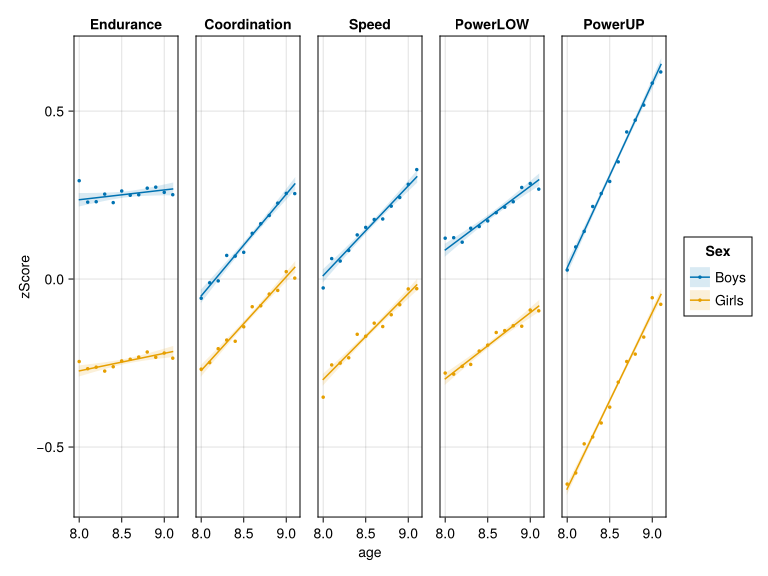

Figure 1: Age trends by sex for each Test for the full data set

```julia
let
  design1 = mapping(:age, :zScore; color=:Sex, col=:Test)
  lines1 = design1 * linear()
  means1 = design1 * visual(Scatter; markersize=5)
  draw(data(df2) * means1 + data(df) * lines1;)
end
```

Figure 1 shows performance differences for the **full set of data** between 8.0 and 9.2 years by sex in the five physical fitness tests presented as z-transformed data computed separately for each test.

- `Endurance` = cardiorespiratory endurance (i.e., 6-min-run test),
- `Coordination` = star-run test,
- `Speed` = 20-m linear sprint test,
- `PowerLOW` = power of lower limbs (i.e., standing long jump test),
- `PowerUP` = power of upper limbs (i.e., ball push test),
- SD = standard deviation. Points are binned observed child means; lines are simple regression fits to the observations.

What do the results look like for the stratified subsample? Here the parallelism is much less clear. In the final LMM we test whether the two regression lines in each of the five panels are statistically parallel for this subset of data. That is, we test the interaction of `Sex` and `age` as nested within the levels of `Test`. Most people want to know the signficance of these five Sex x age interactions.

The theoretical focus of the article, however, is on comparisons between tests displayed next to each other. We ask whether the degree of parallelism is statistically the same for `Endurance` and `Coordination` (H1), `Coordination` and `Speed` (H2), `Speed` and `PowerLOW` (H3), and `PowerLow` and `PowerUP` (H4). Hypotheses H1 to H4 require `Sequential Difference` contrasts c1 to c4 for `Test`; they are tested as fixed effects for``H1 x age x Sex`, `H2 x age x Sex`, `H3 x age x Sex`, and `H4 x age x Sex`.

```julia
dat2 = combine(
  groupby(
    select(dat, :, :age => ByRow(x -> round(x; digits=1)) => :age),
    [:Sex, :Test, :age],
  ),
  :zScore => mean => :zScore,
  :zScore => length => :n,
)
```

120×5 DataFrame

95 rows omitted

| Row | Sex Cat… | Test Cat… | age Float64 | zScore Float64 | n Int64 |
| --- | --- | --- | --- | --- | --- |
| 1 | Boys | Speed | 8.0 | 0.0789166 | 22 |
| 2 | Boys | PowerUP | 8.0 | 0.64487 | 22 |
| 3 | Boys | PowerLOW | 8.0 | -0.0195608 | 22 |
| 4 | Boys | Coordination | 8.0 | 0.411284 | 21 |
| 5 | Boys | Endurance | 8.0 | 0.485693 | 22 |
| 6 | Girls | Speed | 8.0 | -0.439071 | 31 |
| 7 | Girls | PowerUP | 8.0 | -0.688219 | 30 |
| 8 | Girls | PowerLOW | 8.0 | -0.343767 | 31 |
| 9 | Girls | Coordination | 8.0 | -0.410926 | 31 |
| 10 | Girls | Endurance | 8.0 | -0.42921 | 30 |
| 11 | Girls | Speed | 8.1 | -0.346915 | 64 |
| 12 | Girls | PowerUP | 8.1 | -0.541795 | 64 |
| 13 | Girls | PowerLOW | 8.1 | -0.198557 | 63 |
| ⋮ | ⋮ | ⋮ | ⋮ | ⋮ | ⋮ |
| 109 | Girls | Coordination | 9.0 | 0.0919877 | 75 |
| 110 | Girls | Endurance | 9.0 | -0.240405 | 71 |
| 111 | Boys | Speed | 9.1 | 0.403568 | 28 |
| 112 | Boys | PowerUP | 9.1 | 0.527349 | 29 |
| 113 | Boys | PowerLOW | 9.1 | 0.445292 | 30 |
| 114 | Boys | Coordination | 9.1 | 0.309464 | 29 |
| 115 | Boys | Endurance | 9.1 | 0.304958 | 30 |
| 116 | Girls | Speed | 9.1 | -0.0798607 | 17 |
| 117 | Girls | PowerUP | 9.1 | -0.482671 | 17 |
| 118 | Girls | PowerLOW | 9.1 | -0.430986 | 16 |
| 119 | Girls | Coordination | 9.1 | -0.57964 | 17 |
| 120 | Girls | Endurance | 9.1 | -0.226234 | 16 |

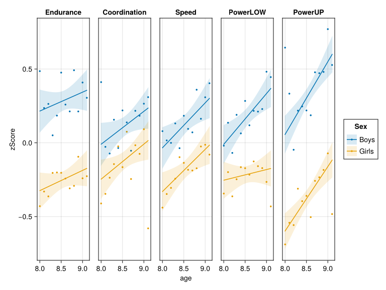

Figure 2: Age trends by sex for each Test for the stratified sample

```julia
let
  design2 = mapping(:age, :zScore; color=:Sex, col=:Test)
  lines2 = design2 * linear()
  means2 = design2 * visual(Scatter; markersize=5)
  draw(data(dat2) * means2 + data(dat) * lines2;)
end
```

Figure 2 Performance differences for **subset of data** between 8.0 and 9.2 years by sex in the five physical fitness tests presented as z-transformed data computed separately for each test.

- `Endurance` = cardiorespiratory endurance (i.e., 6-min-run test),
- `Coordination` = star-run test,
- `Speed` = 20-m linear sprint test,
- `PowerLOW` = power of lower limbs (i.e., standing long jump test),
- `PowerUP` = power of upper limbs (i.e., ball push test),
- SD = standard deviation. Points are binned observed child means; lines are simple regression fits to the observations.

### 2.3.2 Regression on `age` by `Sex` for each `Test`

Another set of relevant statistics are the slopes for the regression of performance on age for boys and girls in each of the five tests. The lines in Figures 1 and 2, however, are computed directly from the raw data with the `linear()` command.

```julia
combine(
  groupby(df, [:Sex, :Test]),
  [:age, :zScore] => simplelinreg => :coef,
)
```

10×3 DataFrame

| Row | Sex Cat… | Test Cat… | coef Tuple… |
| --- | --- | --- | --- |
| 1 | Boys | Endurance | (0.00256718, 0.0291899) |
| 2 | Boys | Coordination | (-2.47279, 0.302819) |
| 3 | Boys | Speed | (-2.12689, 0.267153) |
| 4 | Boys | PowerLOW | (-1.4307, 0.189659) |
| 5 | Boys | PowerUP | (-4.35864, 0.549005) |
| 6 | Girls | Endurance | (-0.692022, 0.0523217) |
| 7 | Girls | Coordination | (-2.50524, 0.279119) |
| 8 | Girls | Speed | (-2.34431, 0.255687) |
| 9 | Girls | PowerLOW | (-1.87241, 0.196917) |
| 10 | Girls | PowerUP | (-4.82271, 0.524799) |

```julia
combine(
  groupby(dat, [:Sex, :Test]),
  [:age, :zScore] => simplelinreg => :coef,
)
```

10×3 DataFrame

| Row | Sex Cat… | Test Cat… | coef Tuple… |
| --- | --- | --- | --- |
| 1 | Boys | Endurance | (-0.809742, 0.128104) |
| 2 | Boys | Coordination | (-1.79221, 0.222836) |
| 3 | Boys | Speed | (-2.4715, 0.304701) |
| 4 | Boys | PowerLOW | (-2.76169, 0.343944) |
| 5 | Boys | PowerUP | (-3.88521, 0.492747) |
| 6 | Girls | Endurance | (-1.42132, 0.137163) |
| 7 | Girls | Coordination | (-2.14706, 0.237589) |
| 8 | Girls | Speed | (-2.62018, 0.286215) |
| 9 | Girls | PowerLOW | (-0.830218, 0.0721176) |
| 10 | Girls | PowerUP | (-4.08892, 0.436415) |

## 2.4 *SeqDiffCoding* of `Test`

*SeqDiffCoding* was used in the publication. This specification tests pairwise differences between the five neighboring levels of `Test`, that is:

- H1: `Star_r` - `Run` (2-1)
- H2: `S20_r` - `Star_r` (3-2)
- H3: `SLJ` - `S20_r` (4-3)
- H4: `BPT` - `SLJ` (5-4)

The levels were sorted such that these contrasts map onto four *a priori* hypotheses; in other words, they are *theoretically* motivated pairwise comparisons. The motivation also encompasses theoretically motivated interactions with `Sex`. The order of levels can also be explicitly specified during contrast construction. This is very useful if levels are in a different order in the dataframe.

The first command recodes names indicating the physical fitness components used in the above figures and tables back to the shorter actual test names. This reduces clutter in LMM outputs.

```julia
recode!(
  dat.Test,
  "Endurance" => "Run",
  "Coordination" => "Star_r",
  "Speed" => "S20_r",
  "PowerLOW" => "SLJ",
  "PowerUP" => "BPT",
)
contrasts = Dict{Symbol,Any}(nm => SeqDiffCoding() for nm in (:Test, :Sex))
```

```
Dict{Symbol, Any} with 2 entries:
  :Test => SeqDiffCoding(nothing)
  :Sex  => SeqDiffCoding(nothing)
```

See the contrast-coding tutorial for why sequential-difference contrasts are not orthogonal and what that implies for the interpretation of correlation parameters between neighboring contrasts, as well as for alternative contrast schemes for these data; contrast coding of visual-attention effects works through the general options on a four-level factor.

# 3 Model complexification

We fit and compare three LMMs with the same fixed-effect structure but increasing complexity of the random-effect structure for `School`. We ignore the other two random factors `Child` and `Cohort` to avoid undue delays when fitting the models.

1. LMM `m_ovi`: allowing only varying intercepts (“Grand Means”);
2. LMM `m_zcp`: adding variance components (VCs) for the four `Test` contrasts, `Sex`, and `age` to LMM `m_ovi`, yielding the zero-correlation parameters LMM;
3. LMM `m_cpx`: adding correlation parameters (CPs) to LMM `m_zcp`; yielding a complex LMM.

In a final part illustrate how to check whether the complex model is supported by the data, rather than leading to a singular fit and, if supported by the data, whether there is an increase in goodness of fit associated with the model complexification.

## 3.1 LMM `m_ovi`

In its random-effect structure (RES) we only vary intercepts (i.e., Grand Means) for `School` (LMM `m_ovi`), that is we allow that the schools differ in the average fitness of its children, average over the five tests.

It is well known that such a simple RES is likely to be anti-conservative with respect to fixed-effect test statistics.

```julia
m_ovi = let
  f = @formula zScore ~ 1 + Test * Sex * a1 + (1 | School)
  fit(MixedModel, f, dat; contrasts, progress)
end
```

Is the model singular (overparameterized, degenerate)? In other words: Is the model not supported by the data?

```julia
issingular(m_ovi)
```

```
false
```

Models varying only in intercepts are almost always supported by the data.

## 3.2 LMM `m_zcp`

In this LMM we allow that schools differ not only in `GM`, but also in the size of the four contrasts defined for `Test`, in the difference between boys and girls (`Sex`) and the developmental gain children achieve within the third grade (`age`).

```julia
m_zcp = let
  f = @formula(
    zScore ~
      1 + Test * Sex * a1 + zerocorr(1 + Test + Sex + a1 | School)
  )
  fit(MixedModel, f, dat; contrasts, progress)
end
```

Depending on sampling, this model estimating variance components for `School` may or may not be supported by the data.

```julia
issingular(m_zcp)
```

```
true
```

## 3.3 LMM `m_cpx`

In the complex LMM investigated in this sequence we give up the assumption of zero-correlation between VCs.

```julia
m_cpx = let
  f = @formula(
    zScore ~ 1 + Test * Sex * a1 + (1 + Test + Sex + a1 | School)
  )
  fit(MixedModel, f, dat; contrasts, progress)
end
```

We also need to see the VCs and CPs of the random-effect structure (RES).

```julia
VarCorr(m_cpx)
```

|  | Column | Variance | Std.Dev | Corr. |  |  |  |  |  |
| --- | --- | --- | --- | --- | --- | --- | --- | --- | --- |
| School | (Intercept) | 0.0876384 | 0.2960378 |  |  |  |  |  |  |
|  | Test: Star_r | 0.0971150 | 0.3116328 | +0.11 |  |  |  |  |  |
|  | Test: S20_r | 0.0356897 | 0.1889171 | +0.14 | -0.77 |  |  |  |  |
|  | Test: SLJ | 0.0059103 | 0.0768787 | -0.59 | -0.35 | -0.01 |  |  |  |
|  | Test: BPT | 0.0314018 | 0.1772055 | -0.54 | +0.01 | +0.30 | -0.02 |  |  |
|  | Sex: Girls | 0.2341024 | 0.4838413 | -0.16 | +0.06 | +0.12 | +0.45 | -0.04 |  |
|  | a1 | 0.6565138 | 0.8102554 | -0.10 | +0.05 | -0.10 | +0.54 | +0.13 | -0.03 |
| Residual |  | 0.7306303 | 0.8547691 |  |  |  |  |  |  |

```julia
issingular(m_cpx)
```

```
false
```

The complex model may or may not be supported by the data.

## 3.4 Model comparisons

The singularity checks depend on the subsample: with the present one, `m_ovi` and `m_cpx` are supported by the data, while the zero-correlation model `m_zcp` is singular (one of its variance components is estimated as zero). Does model complexification also increase the goodness of fit or are we only fitting noise?

### 3.4.1 LRT and goodness-of-fit statistics

As the thee models are strictly hierarchically nested, we compare them with a likelihood-ratio tests (LRT) and AIC and BIC goodness-of-fit statistics derived from them.

```julia
MixedModels.likelihoodratiotest(m_ovi, m_zcp, m_cpx)
```

|  | model-dof | -2 logLik | χ² | χ²-dof | P(>χ²) |
| --- | --- | --- | --- | --- | --- |
| zScore ~ 1 + Test + Sex + a1 + Test & Sex + Test & a1 + Sex & a1 + Test & Sex & a1 + (1 \| School) | 22 | -26250 |  |  |  |
| zScore ~ 1 + Test + Sex + a1 + Test & Sex + Test & a1 + Sex & a1 + Test & Sex & a1 + zerocorr(1 + Test + Sex + a1 \| School) | 28 | -25915 | 336 | 6 | <1e-68 |
| zScore ~ 1 + Test + Sex + a1 + Test & Sex + Test & a1 + Sex & a1 + Test & Sex & a1 + (1 + Test + Sex + a1 \| School) | 49 | -25867 | 47 | 21 | 0.0009 |

```julia
gof_summary = let
  nms = [:m_ovi, :m_zcp, :m_cpx]
  mods = eval.(nms)
  DataFrame(;
    name=nms,
    dof=dof.(mods),
    deviance=deviance.(mods),
    AIC=aic.(mods),
    AICc=aicc.(mods),
    BIC=bic.(mods),
  )
end
```

3×6 DataFrame

| Row | name Symbol | dof Int64 | deviance Float64 | AIC Float64 | AICc Float64 | BIC Float64 |
| --- | --- | --- | --- | --- | --- | --- |
| 1 | m_ovi | 22 | 26250.4 | 26294.4 | 26294.5 | 26452.3 |
| 2 | m_zcp | 28 | 25914.7 | 25970.7 | 25970.9 | 26171.7 |
| 3 | m_cpx | 49 | 25867.5 | 25965.5 | 25966.0 | 26317.3 |

These statistics will depend on sampling. In general, smaller deviance, AIC, and BIC indicate an improvement in goodness of fit. Usually, χ² should be larger than the associated degrees of freedom; for AIC and BIC the decrease should amount to more than 5, according to some literature. Severity of meeting these criteria increases from deviance to AIC to BIC. Therefore, it is not always the case that the criteria are unanimous in their verdict. Basically, the more confirmatory the analysis, the more one may go with deviance and AIC; for exploratory analyses the BIC is probably a better guide. There are grey zones here.

### 3.4.2 Comparing fixed effects of `m_ovi`, `m_zcp`, and `m_cpx`

We check whether enriching the RES changed the significance of fixed effects in the final model.

```julia
m_ovi_fe = DataFrame(coeftable(m_ovi));
m_zcp_fe = DataFrame(coeftable(m_zcp));
m_cpx_fe = DataFrame(coeftable(m_cpx));
m_all = hcat(
  m_ovi_fe[:, [1, 2, 4]],
  leftjoin(
    m_zcp_fe[:, [1, 2, 4]],
    m_cpx_fe[:, [1, 2, 4]];
    on=:Name,
    makeunique=true,
  );
  makeunique=true,
)
rename!(
  m_all,
  "Coef." => "b_ovi",
  "Coef._2" => "b_zcp",
  "Coef._1" => "b_cpx",
  "z" => "z_ovi",
  "z_2" => "z_zcp",
  "z_1" => "z_cpx",
)
m_all2 =
  round.(
    m_all[:, [:b_ovi, :b_zcp, :b_cpx, :z_ovi, :z_zcp, :z_cpx]],
    digits=2,
  )
m_all3 = hcat(m_all.Name, m_all2)
```

20×7 DataFrame

| Row | x1 String | b_ovi Float64 | b_zcp Float64 | b_cpx Float64 | z_ovi Float64 | z_zcp Float64 | z_cpx Float64 |
| --- | --- | --- | --- | --- | --- | --- | --- |
| 1 | (Intercept) | -0.02 | -0.03 | -0.03 | -1.31 | -1.45 | -1.58 |
| 2 | Test: Star_r | -0.03 | -0.02 | -0.01 | -0.87 | -0.58 | -0.45 |
| 3 | Test: S20_r | -0.02 | -0.02 | -0.02 | -0.6 | -0.61 | -0.62 |
| 4 | Test: SLJ | 0.01 | 0.01 | 0.01 | 0.22 | 0.23 | 0.18 |
| 5 | Test: BPT | -0.01 | -0.0 | -0.0 | -0.34 | -0.01 | -0.05 |
| 6 | Sex: Girls | -0.42 | -0.4 | -0.39 | -20.6 | -11.93 | -11.78 |
| 7 | a1 | 0.23 | 0.17 | 0.18 | 6.52 | 3.01 | 3.15 |
| 8 | Test: Star_r & Sex: Girls | 0.31 | 0.31 | 0.31 | 5.07 | 5.39 | 5.31 |
| 9 | Test: S20_r & Sex: Girls | -0.08 | -0.08 | -0.08 | -1.26 | -1.35 | -1.38 |
| 10 | Test: SLJ & Sex: Girls | -0.08 | -0.07 | -0.07 | -1.27 | -1.31 | -1.34 |
| 11 | Test: BPT & Sex: Girls | -0.3 | -0.31 | -0.31 | -5.12 | -5.46 | -5.46 |
| 12 | Test: Star_r & a1 | 0.1 | 0.1 | 0.11 | 0.96 | 1.06 | 1.12 |
| 13 | Test: S20_r & a1 | 0.06 | 0.07 | 0.05 | 0.64 | 0.72 | 0.53 |
| 14 | Test: SLJ & a1 | -0.09 | -0.09 | -0.09 | -0.89 | -0.95 | -0.96 |
| 15 | Test: BPT & a1 | 0.27 | 0.26 | 0.28 | 2.66 | 2.73 | 2.9 |
| 16 | Sex: Girls & a1 | -0.07 | -0.08 | -0.07 | -1.06 | -1.05 | -0.94 |
| 17 | Test: Star_r & Sex: Girls & a1 | 0.01 | 0.04 | 0.05 | 0.04 | 0.19 | 0.24 |
| 18 | Test: S20_r & Sex: Girls & a1 | -0.05 | -0.05 | -0.07 | -0.24 | -0.28 | -0.38 |
| 19 | Test: SLJ & Sex: Girls & a1 | -0.23 | -0.23 | -0.23 | -1.12 | -1.2 | -1.2 |
| 20 | Test: BPT & Sex: Girls & a1 | 0.21 | 0.19 | 0.19 | 1.06 | 0.97 | 1.0 |

The three models usually do **not** differ in fixed-effect estimates. For main effects of `age` and `Sex`, z-values decrease strongly with the complexity of the model (i.e., standard errors are larger). For other coefficients, the changes are not very large and not consistent.

In general, dropping significant variance components and/or correlation parameters may lead to anti-conservative estimates of fixed effects (e.g., Schielzeth & Forstmeier, 2008). Basically, some of the variance allocated to `age` and `Sex` in LMM `m_ovi` could also be due to differences between schools. This ambiguity increased the uncertainty of the respective fixed effects in the other two LMMs.

## 3.5 Fitting an overparameterized LMM

The complex LMM was not overparameterized with respect to `School`, because there are over 400 schools in the data. When the number of units (levels) of a grouping factor is small relative to the number of parameters we are trying to estimate, we often end up with an overparameterized / degenerate random-effect structure.

As an illustration, we fit a full CP matrix for the `Cohort`. As there are only nine cohorts in the data, we may be asking too much to estimate 5*6/2 = 15 VC/CP parameters.

```julia
m_cpxCohort = let
  f = @formula zScore ~ 1 + Test * a1 * Sex + (1 + Test | Cohort)
  fit(MixedModel, f, dat; contrasts, progress)
end
```

```julia
VarCorr(m_cpxCohort)
```

|  | Column | Variance | Std.Dev | Corr. |  |  |  |
| --- | --- | --- | --- | --- | --- | --- | --- |
| Cohort | (Intercept) | 0.0002056 | 0.0143393 |  |  |  |  |
|  | Test: Star_r | 0.0015819 | 0.0397730 | -0.54 |  |  |  |
|  | Test: S20_r | 0.0046825 | 0.0684287 | -0.51 | -0.45 |  |  |
|  | Test: SLJ | 0.0025294 | 0.0502930 | +0.97 | -0.31 | -0.71 |  |
|  | Test: BPT | 0.0022986 | 0.0479434 | -0.64 | +0.99 | -0.33 | -0.44 |
| Residual |  | 0.9219180 | 0.9601656 |  |  |  |  |

```julia
issingular(m_cpxCohort)
```

```
true
```

The model is overparameterized, with correlation parameters estimated close to ±1. How about the **zero-correlation parameter** (zcp) version of this LMM?

```julia
m_zcpCohort = let
  f = @formula(
    zScore ~ 1 + Test * a1 * Sex + zerocorr(1 + Test | Cohort)
  )
  fit(MixedModel, f, dat; contrasts, progress)
end
```

```julia
issingular(m_zcpCohort)
```

```
true
```

This `zcpLMM` is also singular: with the present subsample, all five VCs are estimated as zero. This raises the possibility that LMM `m_oviCohort` might fit as well as LMM `m_zcpCohort`.

```julia
m_oviCohort = let
  f = @formula zScore ~ 1 + Test * a1 * Sex + (1 | Cohort)
  fit(MixedModel, f, dat; contrasts, progress)
end
```

```julia
issingular(m_oviCohort)
```

```
true
```

With the present subsample even this varying-intercepts model estimates the `Cohort` VC as zero — there is essentially no cohort-related variance left in the reduced data. Does LMM `m_zcpCohort` fit noise relative to the LMM `m_oviCohort`?

```julia
MixedModels.likelihoodratiotest(m_oviCohort, m_zcpCohort)
```

|  | model-dof | -2 logLik | χ² | χ²-dof | P(>χ²) |
| --- | --- | --- | --- | --- | --- |
| zScore ~ 1 + Test + a1 + Sex + Test & a1 + Test & Sex + a1 & Sex + Test & a1 & Sex + (1 \| Cohort) | 22 | -26761 |  |  |  |
| zScore ~ 1 + Test + a1 + Sex + Test & a1 + Test & Sex + a1 & Sex + Test & a1 & Sex + zerocorr(1 + Test \| Cohort) | 26 | -26761 | 0 | 4 | 1.0000 |

```julia
gof_summary2 = let
  mods = [m_oviCohort, m_zcpCohort, m_cpxCohort]
  DataFrame(;
    dof=dof.(mods),
    deviance=deviance.(mods),
    AIC=aic.(mods),
    AICc=aicc.(mods),
    BIC=bic.(mods),
  )
end
```

3×5 DataFrame

| Row | dof Int64 | deviance Float64 | AIC Float64 | AICc Float64 | BIC Float64 |
| --- | --- | --- | --- | --- | --- |
| 1 | 22 | 26761.1 | 26805.1 | 26805.2 | 26963.0 |
| 2 | 26 | 26761.1 | 26813.1 | 26813.2 | 26999.8 |
| 3 | 36 | 26758.7 | 26830.7 | 26831.0 | 27089.2 |

Indeed, adding VCs is fitting noise. Again, the goodness of fit statistics unanimously favor the selection of the LMM `m_oviCohort`.

Not shown here, but the `Cohort`-related VCs for the `Test` contrasts could be estimated reliably for the **full** data. Thus, the small number of cohorts does not necessarily prevent the determination of reliable differences between tests across cohorts. What if we include VCs and CPs related to random factors `Child` and `School`?

## 3.6 Fitting the published LMM `m1` to the reduced data

**Warning**

The following LMMs `m1`, `m2`, etc. take a bit longer to fit (a few minutes each on a recent laptop). As elsewhere in these materials, the rendered page restores the fits from a cache via `fit_or_restore`, so re-rendering is fast; delete the corresponding files under `fits/` to force a fresh fit.

LMM `m1` reported in Fühner et al. (2021) included random factors for `School`, `Child`, and `Cohort`. The RES for `School` was specified like in LMM `m_cpx`. The RES for `Child` included VCs and CPs for `Test`, but not for linear developmental gain in the ninth year of life `a1` or `Sex`; they are between-`Child` effects.

The RES for `Cohort` included only VCs, no CPs for `Test`. The *parsimony* was due to the small number of nine levels for this grouping factor.

Here we fit this LMM `m1` for the reduced data. For a different subset of similar size on MacBook Pro [13 | 15 | 16] this took [303 | 250 | 244 ] s; for LMM `m1a` (i.e., dropping 1 school-relate VC for `Sex`), times are [212 | 165 | 160] s. The corresponding `lme4` times for LMM `m1` are [397 | 348 | 195].

Finally, times for fitting the full set of data –not in this script–, for LMM `m1`are [60 | 62 | 85] minutes (!); for LMM `m1a` the times were [46 | 48 | 34] minutes. It was not possible to fit the full set of data with `lme4`; after about 13 to 18 minutes the program stopped with: `Error in eval_f(x, ...) : Downdated VtV is not positive definite.`

```julia
m1 = let
  f = @formula(
    zScore ~
      1 +
      Test * a1 * Sex +
      (1 + Test + a1 + Sex | School) +
      (1 + Test | Child) +
      zerocorr(1 + Test | Cohort)
  )
  fit(MixedModel, f, dat; contrasts, progress)
end
```

```julia
m1
```

|  | Est. | SE | z | p | σ_Child | σ_School | σ_Cohort |
| --- | --- | --- | --- | --- | --- | --- | --- |
| (Intercept) | -0.0274 | 0.0186 | -1.47 | 0.1405 | 0.5780 | 0.2141 | 0.0000 |
| Test: Star_r | -0.0104 | 0.0323 | -0.32 | 0.7474 | 0.6964 | 0.3888 | 0.0000 |
| Test: S20_r | -0.0277 | 0.0317 | -0.87 | 0.3818 | 0.5991 | 0.3225 | 0.0377 |
| Test: SLJ | 0.0038 | 0.0270 | 0.14 | 0.8879 | 0.4485 | 0.2712 | 0.0242 |
| Test: BPT | 0.0067 | 0.0285 | 0.23 | 0.8152 | 0.7018 | 0.2425 | 0.0187 |
| a1 | 0.2359 | 0.0520 | 4.54 | <1e-05 |  | 0.1752 |  |
| Sex: Girls | -0.4194 | 0.0308 | -13.62 | <1e-41 |  | 0.1264 |  |
| Test: Star_r & a1 | 0.1165 | 0.0866 | 1.35 | 0.1786 |  |  |  |
| Test: S20_r & a1 | 0.0393 | 0.0814 | 0.48 | 0.6295 |  |  |  |
| Test: SLJ & a1 | -0.0911 | 0.0738 | -1.23 | 0.2172 |  |  |  |
| Test: BPT & a1 | 0.2680 | 0.0844 | 3.18 | 0.0015 |  |  |  |
| Test: Star_r & Sex: Girls | 0.3112 | 0.0510 | 6.10 | <1e-08 |  |  |  |
| Test: S20_r & Sex: Girls | -0.0674 | 0.0477 | -1.41 | 0.1578 |  |  |  |
| Test: SLJ & Sex: Girls | -0.0748 | 0.0433 | -1.73 | 0.0841 |  |  |  |
| Test: BPT & Sex: Girls | -0.3128 | 0.0496 | -6.31 | <1e-09 |  |  |  |
| a1 & Sex: Girls | -0.0599 | 0.1023 | -0.59 | 0.5581 |  |  |  |
| Test: Star_r & a1 & Sex: Girls | 0.0486 | 0.1731 | 0.28 | 0.7791 |  |  |  |
| Test: S20_r & a1 & Sex: Girls | -0.1097 | 0.1617 | -0.68 | 0.4974 |  |  |  |
| Test: SLJ & a1 & Sex: Girls | -0.1900 | 0.1469 | -1.29 | 0.1959 |  |  |  |
| Test: BPT & a1 & Sex: Girls | 0.1881 | 0.1683 | 1.12 | 0.2636 |  |  |  |
| Residual | 0.5564 |  |  |  |  |  |  |

```julia
VarCorr(m1)
```

|  | Column | Variance | Std.Dev | Corr. |  |  |  |  |  |
| --- | --- | --- | --- | --- | --- | --- | --- | --- | --- |
| Child | (Intercept) | 0.3340612 | 0.5779802 |  |  |  |  |  |  |
|  | Test: Star_r | 0.4849610 | 0.6963914 | +0.13 |  |  |  |  |  |
|  | Test: S20_r | 0.3589109 | 0.5990917 | +0.00 | -0.46 |  |  |  |  |
|  | Test: SLJ | 0.2011919 | 0.4485442 | -0.04 | -0.10 | -0.42 |  |  |  |
|  | Test: BPT | 0.4925463 | 0.7018164 | -0.33 | +0.11 | -0.13 | -0.15 |  |  |
| School | (Intercept) | 0.0458521 | 0.2141311 |  |  |  |  |  |  |
|  | Test: Star_r | 0.1511322 | 0.3887573 | +0.02 |  |  |  |  |  |
|  | Test: S20_r | 0.1040291 | 0.3225354 | +0.11 | -0.61 |  |  |  |  |
|  | Test: SLJ | 0.0735391 | 0.2711809 | -0.15 | -0.13 | -0.42 |  |  |  |
|  | Test: BPT | 0.0588117 | 0.2425113 | -0.13 | +0.01 | +0.12 | -0.41 |  |  |
|  | a1 | 0.0306948 | 0.1751994 | +0.29 | -0.19 | +0.03 | +0.61 | +0.18 |  |
|  | Sex: Girls | 0.0159679 | 0.1263641 | -0.58 | +0.33 | +0.02 | +0.30 | -0.09 | +0.18 |
| Cohort | (Intercept) | 0.0000000 | 0.0000000 |  |  |  |  |  |  |
|  | Test: Star_r | 0.0000000 | 0.0000000 | . |  |  |  |  |  |
|  | Test: S20_r | 0.0014220 | 0.0377094 | . | . |  |  |  |  |
|  | Test: SLJ | 0.0005858 | 0.0242029 | . | . | . |  |  |  |
|  | Test: BPT | 0.0003508 | 0.0187294 | . | . | . | . |  |  |
| Residual |  | 0.3095329 | 0.5563568 |  |  |  |  |  |  |

```julia
issingular(m1)
```

```
true
```

Depending on the random number seed for the stratified sampling, LMM `m1` may or may not be supported by the data; with the present subsample it is singular.

We also fit an alternative parameterization, estimating VCs and CPs for `Test` scores rather than `Test` effects by replacing the `1 + ...` in the RE terms with `0 + ...`.

```julia
m2 = let
  f = @formula(
    zScore ~
      1 +
      Test * a1 * Sex +
      (0 + Test + a1 + Sex | School) +
      (0 + Test | Child) +
      zerocorr(0 + Test | Cohort)
  )
  fit(MixedModel, f, dat; contrasts, progress)
end
```

```julia
m2
```

|  | Est. | SE | z | p | σ_Child | σ_School | σ_Cohort |
| --- | --- | --- | --- | --- | --- | --- | --- |
| (Intercept) | -0.0286 | 0.0192 | -1.49 | 0.1373 |  |  |  |
| Test: Star_r | -0.0103 | 0.0338 | -0.31 | 0.7596 | 0.8483 | 0.3255 | 0.0294 |
| Test: S20_r | -0.0312 | 0.0370 | -0.84 | 0.3987 | 0.8275 | 0.3074 | 0.0617 |
| Test: SLJ | 0.0082 | 0.0342 | 0.24 | 0.8092 | 0.7861 | 0.2606 | 0.0258 |
| Test: BPT | 0.0062 | 0.0291 | 0.21 | 0.8305 | 0.7546 | 0.2542 | 0.0000 |
| a1 | 0.2327 | 0.0521 | 4.47 | <1e-05 |  | 0.1717 |  |
| Sex: Girls | -0.4198 | 0.0308 | -13.62 | <1e-41 |  | 0.1275 |  |
| Test: Star_r & a1 | 0.1156 | 0.0870 | 1.33 | 0.1839 |  |  |  |
| Test: S20_r & a1 | 0.0250 | 0.0821 | 0.30 | 0.7612 |  |  |  |
| Test: SLJ & a1 | -0.0670 | 0.0747 | -0.90 | 0.3695 |  |  |  |
| Test: BPT & a1 | 0.2635 | 0.0845 | 3.12 | 0.0018 |  |  |  |
| Test: Star_r & Sex: Girls | 0.3110 | 0.0510 | 6.10 | <1e-08 |  |  |  |
| Test: S20_r & Sex: Girls | -0.0692 | 0.0477 | -1.45 | 0.1467 |  |  |  |
| Test: SLJ & Sex: Girls | -0.0726 | 0.0432 | -1.68 | 0.0931 |  |  |  |
| Test: BPT & Sex: Girls | -0.3134 | 0.0496 | -6.32 | <1e-09 |  |  |  |
| a1 & Sex: Girls | -0.0579 | 0.1023 | -0.57 | 0.5714 |  |  |  |
| Test: Star_r & a1 & Sex: Girls | 0.0486 | 0.1731 | 0.28 | 0.7788 |  |  |  |
| Test: S20_r & a1 & Sex: Girls | -0.0988 | 0.1616 | -0.61 | 0.5409 |  |  |  |
| Test: SLJ & a1 & Sex: Girls | -0.2008 | 0.1467 | -1.37 | 0.1710 |  |  |  |
| Test: BPT & a1 & Sex: Girls | 0.1894 | 0.1682 | 1.13 | 0.2602 |  |  |  |
| Test: Run |  |  |  |  | 0.8177 | 0.3007 | 0.0000 |
| Residual | 0.4232 |  |  |  |  |  |  |

```julia
issingular(m2)
```

```
true
```

Depending on the random number generator seed, the model may or may not be supported in the alternative parameterization of scores. The fixed-effects profile is not affected (see the model comparisons below).

```julia
VarCorr(m2)
```

|  | Column | Variance | Std.Dev | Corr. |  |  |  |  |  |
| --- | --- | --- | --- | --- | --- | --- | --- | --- | --- |
| Child | Test: Run | 0.6685769 | 0.8176655 |  |  |  |  |  |  |
|  | Test: Star_r | 0.7196973 | 0.8483498 | +0.46 |  |  |  |  |  |
|  | Test: S20_r | 0.6848056 | 0.8275298 | +0.47 | +0.56 |  |  |  |  |
|  | Test: SLJ | 0.6179891 | 0.7861228 | +0.51 | +0.56 | +0.65 |  |  |  |
|  | Test: BPT | 0.5694333 | 0.7546081 | +0.17 | +0.32 | +0.32 | +0.37 |  |  |
| School | Test: Run | 0.0904482 | 0.3007460 |  |  |  |  |  |  |
|  | Test: Star_r | 0.1059671 | 0.3255260 | +0.23 |  |  |  |  |  |
|  | Test: S20_r | 0.0944839 | 0.3073823 | +0.45 | +0.48 |  |  |  |  |
|  | Test: SLJ | 0.0679284 | 0.2606308 | +0.54 | +0.41 | +0.55 |  |  |  |
|  | Test: BPT | 0.0646129 | 0.2541907 | +0.37 | +0.26 | +0.51 | +0.56 |  |  |
|  | a1 | 0.0294933 | 0.1717361 | +0.14 | -0.10 | -0.06 | +0.55 | +0.74 |  |
|  | Sex: Girls | 0.0162487 | 0.1274703 | -0.85 | -0.40 | -0.42 | -0.16 | -0.25 | +0.19 |
| Cohort | Test: Run | 0.0000000 | 0.0000000 |  |  |  |  |  |  |
|  | Test: Star_r | 0.0008625 | 0.0293682 | . |  |  |  |  |  |
|  | Test: S20_r | 0.0038116 | 0.0617382 | . | . |  |  |  |  |
|  | Test: SLJ | 0.0006674 | 0.0258334 | . | . | . |  |  |  |
|  | Test: BPT | 0.0000000 | 0.0000000 | . | . | . | . |  |  |
| Residual |  | 0.1790652 | 0.4231610 |  |  |  |  |  |  |

## 3.7 Principle Component Analysis of Random Effect Structure (rePCA)

The `ìssingular()` command is sort of a shortcut for a quick inspection of the principle components (PCs) of the variance-covariance matrix of the RES. With the `MixedModels.PCA()` command, we also obtain information about the amount of cumulative variance accounted for as we add PCs.

The output also provides PC loadings which may facilitate interpretation of the CP matrices (if estimated). See Fühner et al. (2021) for an application.

## 3.8 Effects in RES

For every random factor, `MixedModels.PCA()` extracts as many PCs as there are VCs. Therefore, the cumulation of variance across PCs within a random factor will always add up to 100% – at the latest with the last VC, but, in the case of overparameterized LMMs, the ceiling will be reached earlier. The final PCs are usually quite small.

PCs are extracted in the order of the amount of unique variance they account for. The first PC accounts for the largest and the final PC for the least amount of variance. The number the PCs with percent variance above a certain threshold indicates the number of weighted composites needed and reflects the dimensionality of the orthogonal space within which (almost) all the variance can be accounted for. The weights for forming composite scores are the listed loadings. For ease of interpretation it is often useful to change the sign of some composite scores.

The PCA for LMM `m1` shows that each of the five PCs for `Child` accounts for a non-zero percent of unique variance.

For `School` fewer than seven PCs have unique variance. The exact number depends on sampling. The overparameterization of `School` might be resolved when the CPs for `Sex` are dropped from the LMM.

`Cohort` was estimated with CPs forced to zero. Therefore, the VCs were forced to be orthogonal; they already represent the PCA solution. However, depending on sampling, not all PCs may be identified for this random factor either.

Importantly, again depending on sampling, a non-singular fit does not imply that unique variance is associated with all PCs (i.e., not for last PC for `School`). Embrace uncertainty!

```julia
MixedModels.PCA(m1)
```

```
(Child =
Principal components based on correlation matrix
 (Intercept)    1.0     .      .      .      .
 Test: Star_r   0.13   1.0     .      .      .
 Test: S20_r    0.0   -0.46   1.0     .      .
 Test: SLJ     -0.04  -0.1   -0.42   1.0     .
 Test: BPT     -0.33   0.11  -0.13  -0.15   1.0

Normalized cumulative variances:
[0.3183, 0.5873, 0.8223, 0.9387, 1.0]

Component loadings
                 PC1    PC2    PC3    PC4   PC5
 (Intercept)    0.0   -0.65  -0.41  -0.64  0.01
 Test: Star_r   0.53   0.01  -0.58   0.37  0.49
 Test: S20_r   -0.73   0.02  -0.07   0.04  0.68
 Test: SLJ      0.4   -0.26   0.69  -0.17  0.52
 Test: BPT      0.15   0.72  -0.11  -0.65  0.17, School =
Principal components based on correlation matrix
 (Intercept)    1.0     .      .      .      .      .      .
 Test: Star_r   0.02   1.0     .      .      .      .      .
 Test: S20_r    0.11  -0.61   1.0     .      .      .      .
 Test: SLJ     -0.15  -0.13  -0.42   1.0     .      .      .
 Test: BPT     -0.13   0.01   0.12  -0.41   1.0     .      .
 a1             0.29  -0.19   0.03   0.61   0.18   1.0     .
 Sex: Girls    -0.58   0.33   0.02   0.3   -0.09   0.18   1.0

Normalized cumulative variances:
[0.2898, 0.5304, 0.7346, 0.8948, 1.0, 1.0, 1.0]

Component loadings
                 PC1    PC2    PC3    PC4    PC5    PC6    PC7
 (Intercept)   -0.3   -0.3    0.59  -0.14   0.44   0.44  -0.25
 Test: Star_r   0.3    0.51   0.33  -0.31   0.4   -0.5   -0.19
 Test: S20_r   -0.45  -0.23  -0.48   0.15   0.46  -0.42  -0.34
 Test: SLJ      0.54  -0.45   0.06   0.11  -0.24  -0.1   -0.65
 Test: BPT     -0.23   0.11  -0.28  -0.79  -0.3    0.17  -0.35
 a1             0.22  -0.61  -0.03  -0.48   0.16  -0.27   0.5
 Sex: Girls     0.47   0.12  -0.48  -0.04   0.51   0.52   0.0, Cohort =
Principal components based on correlation matrix
 (Intercept)   0.0  .    .    .    .
 Test: Star_r  0.0  0.0  .    .    .
 Test: S20_r   0.0  0.0  1.0  .    .
 Test: SLJ     0.0  0.0  0.0  1.0  .
 Test: BPT     0.0  0.0  0.0  0.0  1.0

Normalized cumulative variances:
[0.3333, 0.6667, 1.0, 1.0, 1.0]

Component loadings
                PC1   PC2   PC3   PC4   PC5
 (Intercept)   0.0   0.0   0.0   1.0   0.0
 Test: Star_r  0.0   0.0   0.0   0.0   1.0
 Test: S20_r   1.0   0.0   0.0   0.0   0.0
 Test: SLJ     0.0   1.0   0.0   0.0   0.0
 Test: BPT     0.0   0.0   1.0   0.0   0.0)
```

### 3.8.1 Scores in RES

Now lets looks at the PCA results for the alternative parameterization of LMM `m2`. It is important to note that the reparameterization to base estimates of VCs and CPs on scores rather than effects applies only to the `Test` factor (i.e., the first factor in the formula); VCs for `Sex` and `age` refer to the associated effects.

Depending on sampling, the difference between LMM `m1` and LMM `m2` may show that overparameterization according to PCs may depend on the specification chosen for the other the random-effect structure.

**Note**

For the *complete* data, all PCs had unique variance associated with them.

```julia
MixedModels.PCA(m2)
```

```
(Child =
Principal components based on correlation matrix
 Test: Run     1.0    .     .     .     .
 Test: Star_r  0.46  1.0    .     .     .
 Test: S20_r   0.47  0.56  1.0    .     .
 Test: SLJ     0.51  0.56  0.65  1.0    .
 Test: BPT     0.17  0.32  0.32  0.37  1.0

Normalized cumulative variances:
[0.561, 0.7307, 0.8375, 0.9313, 1.0]

Component loadings
                 PC1    PC2    PC3    PC4    PC5
 Test: Run     -0.42   0.45   0.78  -0.03  -0.13
 Test: Star_r  -0.47   0.07  -0.32  -0.82   0.05
 Test: S20_r   -0.49   0.08  -0.41   0.41  -0.64
 Test: SLJ     -0.51   0.03  -0.15   0.4    0.75
 Test: BPT     -0.31  -0.89   0.33  -0.03  -0.1, School =
Principal components based on correlation matrix
 Test: Run      1.0     .      .      .      .      .      .
 Test: Star_r   0.23   1.0     .      .      .      .      .
 Test: S20_r    0.45   0.48   1.0     .      .      .      .
 Test: SLJ      0.54   0.41   0.55   1.0     .      .      .
 Test: BPT      0.37   0.26   0.51   0.56   1.0     .      .
 a1             0.14  -0.1   -0.06   0.55   0.74   1.0     .
 Sex: Girls    -0.85  -0.4   -0.42  -0.16  -0.25   0.19   1.0

Normalized cumulative variances:
[0.467, 0.7177, 0.8557, 0.93, 1.0, 1.0, 1.0]

Component loadings
                 PC1    PC2    PC3    PC4    PC5    PC6    PC7
 Test: Run     -0.43   0.22   0.52   0.05   0.27   0.24   0.6
 Test: Star_r  -0.31   0.25  -0.6    0.62  -0.17  -0.02   0.24
 Test: S20_r   -0.41   0.17  -0.37  -0.71  -0.0   -0.37   0.16
 Test: SLJ     -0.44  -0.25  -0.17   0.08   0.68   0.17  -0.47
 Test: BPT     -0.42  -0.37   0.01  -0.16  -0.59   0.55  -0.11
 a1            -0.22  -0.67   0.19   0.24  -0.09  -0.61   0.18
 Sex: Girls     0.35  -0.47  -0.41  -0.15   0.27   0.32   0.54, Cohort =
Principal components based on correlation matrix
 Test: Run     0.0  .    .    .    .
 Test: Star_r  0.0  1.0  .    .    .
 Test: S20_r   0.0  0.0  1.0  .    .
 Test: SLJ     0.0  0.0  0.0  1.0  .
 Test: BPT     0.0  0.0  0.0  0.0  0.0

Normalized cumulative variances:
[0.3333, 0.6667, 1.0, 1.0, 1.0]

Component loadings
                PC1   PC2   PC3   PC4   PC5
 Test: Run     0.0   0.0   0.0   1.0   0.0
 Test: Star_r  1.0   0.0   0.0   0.0   0.0
 Test: S20_r   0.0   1.0   0.0   0.0   0.0
 Test: SLJ     0.0   0.0   1.0   0.0   0.0
 Test: BPT     0.0   0.0   0.0   0.0   1.0)
```

## 3.9 Summary of results for stratified subset of data

Returning to the theoretical focus of the article, the significant main effects of `age` and `Sex` are replicated, as are the interaction between `age` and the c4 contrast and the interactions between `Sex` and two test contrasts (c1, c4). The remaining contrast interactions reported for the full data do not reach significance in this subsample. Obviously, the subset of data is much noisier than the full set.

# 4 `Age x Sex` nested in levels of `Test`

In this final LMM, we test *post-hoc* five `age x Sex` interactions by nesting the interaction in the levels of `Test`. As this LMM `m2_nested` is a reparameterization of LMM `m2`.

```julia
m2_nested = let
  f = @formula(
    zScore ~
      1 +
      Test +
      Test & (a1 * Sex) +
      (0 + Test + a1 + Sex | School) +
      (0 + Test | Child) +
      zerocorr(0 + Test | Cohort)
  )
  fit(MixedModel, f, dat; contrasts, progress)
end
```

```julia
m2_nested
```

|  | Est. | SE | z | p | σ_Child | σ_School | σ_Cohort |
| --- | --- | --- | --- | --- | --- | --- | --- |
| (Intercept) | -0.0286 | 0.0192 | -1.49 | 0.1372 |  |  |  |
| Test: Star_r | -0.0103 | 0.0338 | -0.31 | 0.7595 | 0.8510 | 0.3256 | 0.0294 |
| Test: S20_r | -0.0312 | 0.0370 | -0.84 | 0.3988 | 0.8303 | 0.3074 | 0.0618 |
| Test: SLJ | 0.0082 | 0.0342 | 0.24 | 0.8093 | 0.7890 | 0.2606 | 0.0259 |
| Test: BPT | 0.0062 | 0.0291 | 0.21 | 0.8305 | 0.7576 | 0.2542 | 0.0000 |
| Test: Run & a1 | 0.0993 | 0.0757 | 1.31 | 0.1893 |  |  |  |
| Test: Star_r & a1 | 0.2149 | 0.0784 | 2.74 | 0.0061 |  |  |  |
| Test: S20_r & a1 | 0.2399 | 0.0771 | 3.11 | 0.0019 |  |  |  |
| Test: SLJ & a1 | 0.1729 | 0.0728 | 2.37 | 0.0176 |  |  |  |
| Test: BPT & a1 | 0.4364 | 0.0704 | 6.20 | <1e-09 |  |  |  |
| Test: Run & Sex: Girls | -0.5354 | 0.0448 | -11.95 | <1e-32 |  |  |  |
| Test: Star_r & Sex: Girls | -0.2244 | 0.0462 | -4.86 | <1e-05 |  |  |  |
| Test: S20_r & Sex: Girls | -0.2936 | 0.0450 | -6.52 | <1e-10 |  |  |  |
| Test: SLJ & Sex: Girls | -0.3662 | 0.0428 | -8.56 | <1e-16 |  |  |  |
| Test: BPT & Sex: Girls | -0.6795 | 0.0415 | -16.37 | <1e-59 |  |  |  |
| Test: Run & a1 & Sex: Girls | 0.0049 | 0.1503 | 0.03 | 0.9740 |  |  |  |
| Test: Star_r & a1 & Sex: Girls | 0.0535 | 0.1548 | 0.35 | 0.7295 |  |  |  |
| Test: S20_r & a1 & Sex: Girls | -0.0453 | 0.1511 | -0.30 | 0.7645 |  |  |  |
| Test: SLJ & a1 & Sex: Girls | -0.2460 | 0.1437 | -1.71 | 0.0869 |  |  |  |
| Test: BPT & a1 & Sex: Girls | -0.0566 | 0.1396 | -0.41 | 0.6850 |  |  |  |
| Test: Run |  |  |  |  | 0.8204 | 0.3008 | 0.0000 |
| a1 |  |  |  |  |  | 0.1719 |  |
| Sex: Girls |  |  |  |  |  | 0.1274 |  |
| Residual | 0.4177 |  |  |  |  |  |  |

The results show that none of the interactions in the panels of Figure 2 is significant. The size and direction of interaction effects correspond with what is shown in Figure 2.

### 4.0.1 Model comparisons

```julia
gof_summary3 = let
  nms = [:m1, :m2, :m2_nested]
  mods = eval.(nms)
  DataFrame(;
    name=nms,
    dof=dof.(mods),
    deviance=deviance.(mods),
    AIC=aic.(mods),
    AICc=aicc.(mods),
    BIC=bic.(mods),
  )
end
```

3×6 DataFrame

| Row | name Symbol | dof Int64 | deviance Float64 | AIC Float64 | AICc Float64 | BIC Float64 |
| --- | --- | --- | --- | --- | --- | --- |
| 1 | m1 | 69 | 24641.9 | 24779.9 | 24780.9 | 25275.4 |
| 2 | m2 | 69 | 24637.5 | 24775.5 | 24776.5 | 25270.9 |
| 3 | m2_nested | 69 | 24637.5 | 24775.5 | 24776.5 | 25270.9 |

In principle, the models should yield the same deviance. When models are not supported by the data, that is for singular models, there may be small differences between deviances for these reparameterizations. During optimization such models search for the absolute minimum in a very shallow surface and may end up in a local minimum instead.

## 4.1 See Also

- Mixed Models Tutorial: Contrast Coding — applies a full range of contrast schemes (effect, Helmert, hypothesis, PCA-based) to the same Emotikon dataset.
- Emotikon: Comparing Original and Transformed Metrics — investigates whether the age × Sex × Test interaction changes when tasks are analyzed in their original time metric rather than speed.
- Creating Multi-Panel Plots — reproduces the publication figure from Fühner et al. (2021) using AlgebraOfGraphics.
- MixedModels.jl cheatsheet — a tour of the extractor functions for inspecting a fitted model, formerly a section of this page.

Fühner, T., Granacher, U., Golle, K., & Kliegl, R. (2021). Age and sex effects in physical fitness components of 108,295 third graders including 515 primary schools and 9 cohorts. *Scientific Reports*, *11*(1). https://doi.org/10.1038/s41598-021-97000-4

Schielzeth, H., & Forstmeier, W. (2008). Conclusions beyond support: Overconfident estimates in mixed models. *Behavioral Ecology*, *20*(2), 416–420. https://doi.org/10.1093/beheco/arn145

## 4.2 Exercises

1. **Read the PCA.** Inspect the principal-components decomposition of the random effects. How many components carry most of the variance, and how does that inform which random-effects terms to keep?

**NoteSolution**

If the first few components account for nearly all of the random-effects variance, the remaining dimensions are effectively redundant — the data do not support a full-rank random-effects covariance. That is the quantitative basis for reducing the random-effects structure (e.g. dropping near-zero components or correlation parameters) rather than guessing.

2. **Add a comparison.** Add a contrast for the `Test` factor that encodes a comparison you find substantively interesting, refit, and check whether it changes the conclusions about the age-by-sex interaction.

**NoteSolution**

Because re-coding a factor does not change the model fit, the omnibus conclusions (and the age-by-sex interaction) are unaffected; what changes is which specific comparison each `Test` coefficient reports. Use this to confirm that your substantive comparison is or is not significant without disturbing the rest of the model. See Mixed Models Tutorial: Contrast Coding.

*This page was rendered from git revision [29e8d33](https://github.com/RePsychLing/SMLP2026/tree/29e8d33  
) using Quarto 1.10.18 and Julia 1.12.7.*

Back to top